# Exclusion des radiographies des patients avec une pneumonie mixte (bacteria + virus)

# Preprocessing des images

```python
import cv2

def preprocess_image(path, size=(130, 95), apply_clahe=False):
    """
    Charge une image, supprime les bordures noires et les lettres parasites,
    la passe en niveaux de gris, applique optionnellement CLAHE, et la redimensionne.
    """
    try:
        # Chargement de l'image en niveaux de gris directe avec OpenCV
        img_raw = cv2.imread(str(path), cv2.IMREAD_GRAYSCALE)
        if img_raw is None:
            raise ValueError("Impossible de charger l'image avec OpenCV.")

        # --- ÉTAPE A : SUPPRESSION DES BORDURES NOIRES ---
        # On crée un masque binaire des zones non-noires (seuil à 10 sur 255)
        _, thresh_crop = cv2.threshold(img_raw, 10, 255, cv2.THRESH_BINARY)
        # On trouve les contours de la cage thoracique
        contours, _ = cv2.findContours(thresh_crop, cv2.RETR_EXTERNAL, cv2.CHAIN_APPROX_SIMPLE)

        if contours:
            # On prend le plus grand contour qui est (normalement) la zone de la radio elle-même
            largest_contour = max(contours, key=cv2.contourArea)
            x, y, w, h = cv2.boundingRect(largest_contour)
            # On rogne l'image sur ce contour
            img_processed = img_raw[y:y+h, x:x+w]
        else:
            img_processed = img_raw.copy()

        # --- ÉTAPE B : SUPPRESSION DES LETTRES PARASITES (L, R) ---
        # Les lettres et annotations sont généralement d'un blanc pur (proche de 255)
        # On crée un masque pour cibler ce blanc très intense
        _, text_mask = cv2.threshold(img_processed, 250, 255, cv2.THRESH_BINARY)

        # recommandé : On dilate légèrement le masque pour bien englober les bords des lettres
        kernel = cv2.getStructuringElement(cv2.MORPH_RECT, (3, 3))
        text_mask = cv2.dilate(text_mask, kernel, iterations=1)

        # On applique l'inpainting pour effacer le texte en le remplaçant par le voisinage direct
        img_processed = cv2.inpaint(img_processed, text_mask, inpaintRadius=3, flags=cv2.INPAINT_TELEA)

        # --- ÉTAPE C : CLAHE pour accentuer le contraste ---
        if apply_clahe:
            clip = 2.0
            grid = 8
            clahe = cv2.createCLAHE(clipLimit=clip, tileGridSize=(grid, grid))
            img_processed = clahe.apply(img_processed)

        # --- ÉTAPE D : REDIMENSIONNEMENT FINALE ---
        # OpenCV utilise (largeur, hauteur), donc (130, 95)
        img_resized = cv2.resize(img_processed, size, interpolation=cv2.INTER_AREA)

        # Normalisation finale par la division par 255
        return img_resized / 255.0

    except Exception as e:
        print(f"Erreur sur l'image {path} : {e}")
        return None
```

```python
# Visualisation des images avant / après prétraitement

def show_raw_and_processed(df, n=3, size=(130, 95), apply_clahe=False):
    """
    Affiche n images du dataset :
    - Ligne 1 : Image originale brute (RAW)
    - Ligne 2 : Image après preprocess_image (accepte False, True, ou "random")
    """
    # On s'assure de ne pas demander plus d'images que le DataFrame n'en contient
    n = min(n, len(df))

    plt.figure(figsize=(5 * n, 8))

    for i in range(n):
        row = df.iloc[i]
        path = row["path"]
        label = row["label"]

        # 1. Chargement de l'image originale brute
        img_raw = Image.open(path)

        # 2. Traitement
        img_proc = preprocess_image(path, size=size, apply_clahe=apply_clahe)

        if img_proc is None:
            continue

        # Ligne 1 : Image brute (RAW)
        plt.subplot(2, n, i + 1)
        plt.imshow(img_raw, cmap="gray")
        plt.axis("off")
        plt.title(f"RAW\nLabel: {label}")

        # Ligne 2 : Image traitée (S'adapte automatiquement au mode choisi)
        plt.subplot(2, n, i + 1 + n)
        plt.imshow(img_proc, cmap="gray")
        plt.axis("off")

        # Dynamisation du titre si le traitement est appliqué
        if apply_clahe is True:
            title_type = "PREPROCESSED (STANDARD CLAHE)"
        else:
            title_type = "PREPROCESSED (STANDARD)"

        plt.title(f"{title_type}\n{size[0]}×{size[1]}")

    plt.suptitle("Comparatif Images Brutes vs Prétraitées", fontsize=16)
    plt.tight_layout()
    plt.show()
```

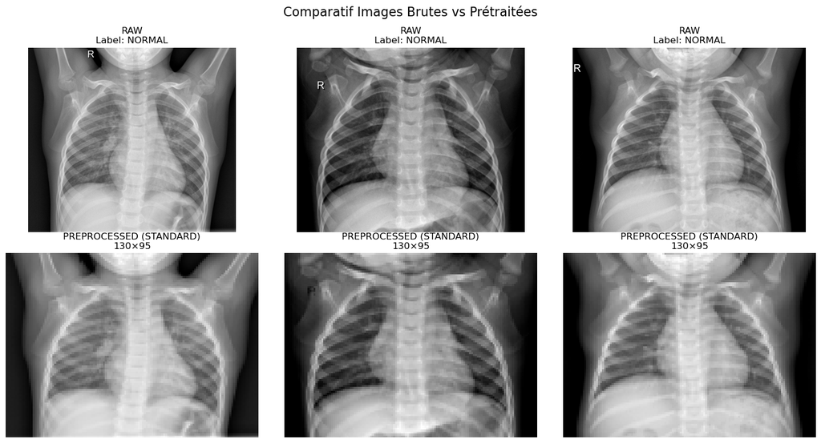

```python
show_raw_and_processed(df[df["split"] == "train"], n=3, apply_clahe=False)
```

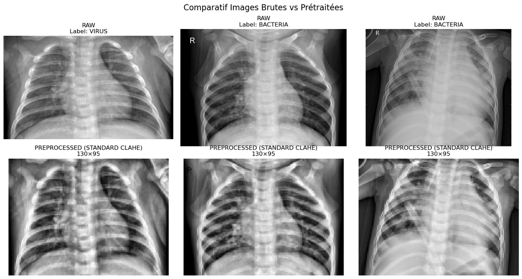

```python
show_raw_and_processed((df[df["split"] == "train"]).sample(n=3), n=3, size=(130, 95), apply_clahe=True)
```

# Train-test-split

## Fusion datasets de train + valid

```python
df_train = df[df["split"] == "train"]
df_val = df[df["split"] == "val"]

df_train_full = pd.concat([df_train, df_val], ignore_index=True)
df_train_full["split"] = "train"
```

```python
len(df_train_full)
```

```
4775
```

## Train-test-split stratifié 80/20

```python
# création du dataset de validation
from sklearn.model_selection import train_test_split

df_train, df_valid = train_test_split(
    df_train_full,
    test_size=0.2,
    stratify=df_train_full["label"],
    random_state=42
)
```

```python
df_test = df[df["split"] == "test"]

print("Nb images dans le jeu de train :", len(df_train))
print("Nb images dans le jeu de valid:", len(df_valid))
print("Nb images dans le jeu de test :", len(df_test))
```

```
Nb images dans le jeu de train : 3820
Nb images dans le jeu de valid: 955
Nb images dans le jeu de test : 304
```

```python
print(df_train["label"].value_counts())
print(df_valid["label"].value_counts())
```

```
label
BACTERIA    1746
NORMAL      1079
VIRUS        995
Name: count, dtype: int64
label
BACTERIA    437
NORMAL      270
VIRUS       248
Name: count, dtype: int64
```

# Récupération des X (images) et y (étiquettes) pour chaque jeu

```python
def build_dataset(df_subset, size=(130, 95), apply_clahe=False):
    label_mapping = {"NORMAL": 0, "BACTERIA": 1, "VIRUS": 2}
    y = (
        df_subset["label"]
        .map(label_mapping)
        .fillna(-1)
        .to_numpy(dtype=np.int64)
    )

    # Liste de matrices 2D, avec le prétraitement CLAHE activé
    X_list = [
        preprocess_image(p, size, apply_clahe=apply_clahe) for p in df_subset["path"]
    ]
    return np.array(X_list), y
```

```python
X_test, y_test = build_dataset(df_test, apply_clahe=True)
X_train, y_train = build_dataset(df_train, apply_clahe=True)
X_valid, y_valid = build_dataset(df_valid, apply_clahe=True)
```

```python
print(X_train[0:1], y_train[0:1])
```

```
[[[0.21176471 0.2        0.21568627 ... 0.20392157 0.15294118 0.10588235]
  [0.17254902 0.16862745 0.2        ... 0.16470588 0.11764706 0.06666667]
  [0.16470588 0.15294118 0.2        ... 0.14117647 0.08235294 0.02745098]
  ...
  [0.01176471 0.01176471 0.01176471 ... 0.01176471 0.01176471 0.01176471]
  [0.01176471 0.01176471 0.01176471 ... 0.01176471 0.01176471 0.01176471]
  [0.01176471 0.01176471 0.01176471 ... 0.01176471 0.01176471 0.01176471]]] [0]
```

```python
print(X_train.shape, y_train.shape)
```

```
(3820, 95, 130) (3820,)
```

```python
X_train = X_train.reshape(X_train.shape[0], -1)
X_valid = X_valid.reshape(X_valid.shape[0], -1)
X_test  = X_test.reshape(X_test.shape[0], -1)
```

```python
print(type(X_train))
```

```
<class 'numpy.ndarray'>
```

# Distribution des classes dans chaque jeu

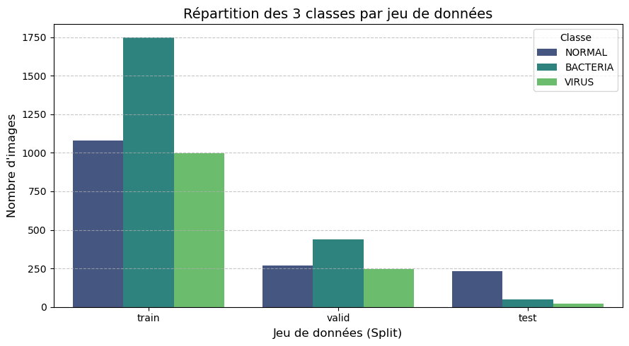

```python
import seaborn as sns

classes = ["NORMAL", "BACTERIA", "VIRUS"]

# np.bincount compte les occurrences de 0, 1 et 2 d'un seul coup
df_counts = pd.DataFrame({
    "NORMAL":   [np.bincount(y_train)[0], np.bincount(y_valid)[0], np.bincount(y_test)[0]],
    "BACTERIA": [np.bincount(y_train)[1], np.bincount(y_valid)[1], np.bincount(y_test)[1]],
    "VIRUS":    [np.bincount(y_train)[2], np.bincount(y_valid)[2], np.bincount(y_test)[2]],
    "split":    ["train", "valid", "test"]
})

# 2. On reformate le DataFrame pour Seaborn (format "Long")
df_melted = df_counts.melt(id_vars="split", var_name="label", value_name="count")

# 3. Plot avec Seaborn
plt.figure(figsize=(9, 5))
sns.barplot(
    data=df_melted,
    x="split",
    y="count",
    hue="label",
    hue_order=classes,
    palette="viridis"
)

plt.title("Répartition des 3 classes par jeu de données", fontsize=14)
plt.xlabel("Jeu de données (Split)", fontsize=12)
plt.ylabel("Nombre d'images", fontsize=12)
plt.legend(title="Classe")
plt.grid(axis='y', linestyle='--', alpha=0.7)
plt.tight_layout()
plt.show()
```

# PCA

=> PCA pour réduire le nb de dimensions (et donc les effets d'une variance trop élevée): peu d'images + accélère l'entrainement -> limite le surapprentissage S'effectue toujours sur les données standardisées

```python
from sklearn.preprocessing import StandardScaler

scaler = StandardScaler()
X_train_sc = scaler.fit_transform(X_train)
X_val_sc = scaler.transform(X_valid)
X_test_sc = scaler.transform(X_test)
```

```python
# on fit sur X_train_sc uniquement

from sklearn.decomposition import PCA

pca_model = PCA()
pca_model.fit(X_train_sc)
```

```
PCA()
```

## Cumulative Explained Variance

https://medium.com/@megha.natarajan/understanding-cumulative-explained-variance-in-pca-with-python-653e3592a77c

"Principal Component Analysis (PCA) is a technique used to emphasize variation and capture strong patterns in a dataset. But how can we measure the effectiveness of PCA? This is where the Cumulative Explained Variance plot comes into play. [...] Visually, the Cumulative Explained Variance plot often shows a sharp turn or “elbow,” indicating the point at which adding more components has diminishing returns in terms of explained variance."

```python
individual_variances = pca_model.explained_variance_ratio_

# cumulative explained variance
cumulative_variances = np.cumsum(individual_variances)
cumulative_variances.shape

for i in range(len(cumulative_variances)):
    if cumulative_variances[i] >= 0.95 and cumulative_variances[i] <= 0.96:
        print(f"{i}, avec no composantes {cumulative_variances[i]}")
```

```
818, avec no composantes 0.9500340305328425
819, avec no composantes 0.9501090678692005
820, avec no composantes 0.9501839109801634
821, avec no composantes 0.9502585808903778
822, avec no composantes 0.9503331856198806
823, avec no composantes 0.9504075280288474
824, avec no composantes 0.9504818100990431
825, avec no composantes 0.9505559288960161
826, avec no composantes 0.9506298056267517
827, avec no composantes 0.9507036155292441
828, avec no composantes 0.9507770511883503
829, avec no composantes 0.9508503576235305
830, avec no composantes 0.9509236045875141
831, avec no composantes 0.9509968159475359
832, avec no composantes 0.9510696281592895
```

[output cut: 140 more lines]

```python
cumulative = np.cumsum(pca_model.explained_variance_ratio_)
n_comp = np.argmax(cumulative >= 0.95)

n_comp
```

```
np.int64(818)
```

```python
pca = PCA(n_components=n_comp, svd_solver='full', random_state=42)

X_train_pca = pca.fit_transform(X_train_sc)
X_valid_pca = pca.transform(X_val_sc)
X_test_pca = pca.transform(X_test_sc)
```

```python
X_train_pca.shape
```

```
(3820, 818)
```

# CLASSIFICATION CLASSES 'NORMAL' VS 'BACTERIA' VS 'VIRUS'

## Recherche hyperparamètres Support Vector Machines Classifier

```python
from sklearn.svm import SVC
```

```python
from sklearn.model_selection import GridSearchCV

# on teste plusieurs hypothèses de poids à appliquer à chaque classe
# en fonction de leur distribution dans le jeu de train
# 0 : NORMAL ; 1: BACTERIA ; 2: VIRUS
hypothèses_poids = [
    {0: 1.8, 2: 0.9, 1: 0.75},

    # Hypothèse B : On booste modérément le Virus pour l'aider face à Bacteria
    {0: 1.8, 2: 1.5, 1: 0.75},

    # Hypothèse C : On booste agressivement le Virus au niveau du Normal
    {0: 1.8, 2: 1.8, 1: 0.75},

    # Hypothèse D : On se focalise uniquement sur le duel Bacteria/Virus en égalisant Normal
    {0: 1.0, 2: 2.0, 1: 0.5}
]

param_grid = {
    "C": [0.1, 1, 10],
    "gamma": ["scale", "auto", 0.01, 0.001],
    "kernel": ["linear", "poly", "rbf", "sigmoid"],
    "class_weight": hypothèses_poids
}

model = SVC(max_iter=10000,
          #class_weight="balanced", # "pénalise" les PNEUMONIA
          random_state=42,
          probability=True)

grid = GridSearchCV(
    model,
    param_grid,
    scoring="roc_auc_ovr", # on cherche à optimiser le ROC AUC et non l'accuracy
    cv=5,
    n_jobs=-1
)

grid.fit(X_train_pca, y_train)
```

```
GridSearchCV(cv=5,
             estimator=SVC(max_iter=10000, probability=True, random_state=42),
             n_jobs=-1,
             param_grid={'C': [0.1, 1, 10],
                         'class_weight': [{0: 1.8, 1: 0.75, 2: 0.9},
                                          {0: 1.8, 1: 0.75, 2: 1.5},
                                          {0: 1.8, 1: 0.75, 2: 1.8},
                                          {0: 1.0, 1: 0.5, 2: 2.0}],
                         'gamma': ['scale', 'auto', 0.01, 0.001],
                         'kernel': ['linear', 'poly', 'rbf', 'sigmoid']},
             scoring='roc_auc_ovr')
```

```python
best_model = grid.best_estimator_
print("Meilleurs hyperparamètres :", grid.best_params_)
```

```
Meilleurs hyperparamètres : {'C': 1, 'class_weight': {0: 1.8, 2: 1.5, 1: 0.75}, 'gamma': 'scale', 'kernel': 'rbf'}
```

# Entrainement SVC avec les meilleurs hyperparamètres

```python
svc = SVC(C=best_model.C,
          gamma=best_model.gamma,
          kernel=best_model.kernel,
          class_weight=best_model.class_weight,
            probability=True,
          max_iter=10000,
          random_state=42)


svc.fit(X_train_pca, y_train)
```

```
SVC(C=1, class_weight={0: 1.8, 1: 0.75, 2: 1.5}, max_iter=10000,
    probability=True, random_state=42)
```

# Performances jeu de train

```python
class_names = ["NORMAL", "BACTERIA", "VIRUS"]
```

```python
y_pred_train = svc.predict(X_train_pca)
```

```python
y_pred_proba_train = svc.predict_proba(X_train_pca)
```

```python
# ROC-AUC score
from sklearn.metrics import roc_auc_score
roc_auc = roc_auc_score(
    y_train,
    y_pred_proba_train,
    multi_class="ovr")

print(f"ROC-AUC (train) : {roc_auc:.3f}")
```

```
ROC-AUC (train) : 0.988
```

```python
from sklearn.metrics import classification_report

print(classification_report(
        y_train,
        y_pred_train,
        target_names=[
            "NORMAL",
            "BACTERIA",
            "VIRUS"
        ]
    ))
```

```
              precision    recall  f1-score   support

      NORMAL       0.98      1.00      0.99      1079
    BACTERIA       0.96      0.88      0.92      1746
       VIRUS       0.83      0.92      0.87       995

    accuracy                           0.93      3820
   macro avg       0.92      0.93      0.93      3820
weighted avg       0.93      0.93      0.93      3820
```

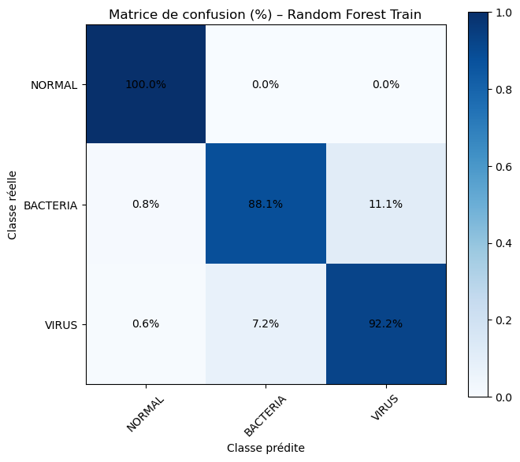

```python
from sklearn.metrics import confusion_matrix

# Matrice de confusion
cm_train = confusion_matrix(y_train, y_pred_train)

# Normalisation par ligne (classe réelle)
cm_normalized = cm_train.astype(float) / cm_train.sum(axis=1, keepdims=True)

plt.figure(figsize=(7, 6))
plt.imshow(cm_normalized, cmap="Blues")
plt.colorbar()

plt.xticks(
    np.arange(len(class_names)),
    class_names,
    rotation=45
)

plt.yticks(
    np.arange(len(class_names)),
    class_names
)

# Affichage des pourcentages dans chaque case
for i in range(len(class_names)):
    for j in range(len(class_names)):
        plt.text(
            j,
            i,
            f"{cm_normalized[i, j]*100:.1f}%",
            ha="center",
            va="center",
            color="black"
        )

plt.xlabel("Classe prédite")
plt.ylabel("Classe réelle")
plt.title("Matrice de confusion (%) – Random Forest Train")

plt.tight_layout()
plt.show()
```

```python
# Sur le jeu de train
for i, true_class in enumerate(class_names):
    for j, pred_class in enumerate(class_names):
        print(
            f"Réel={true_class}, Prédit={pred_class} : {cm_train[i,j]}"
        )
```

```
Réel=NORMAL, Prédit=NORMAL : 1079
Réel=NORMAL, Prédit=BACTERIA : 0
Réel=NORMAL, Prédit=VIRUS : 0
Réel=BACTERIA, Prédit=NORMAL : 14
Réel=BACTERIA, Prédit=BACTERIA : 1539
Réel=BACTERIA, Prédit=VIRUS : 193
Réel=VIRUS, Prédit=NORMAL : 6
Réel=VIRUS, Prédit=BACTERIA : 72
Réel=VIRUS, Prédit=VIRUS : 917
```

```python
for classe, nom in enumerate(class_names):

    TP = cm_train[classe, classe]

    FN = cm_train[classe, :].sum() - TP

    FP = cm_train[:, classe].sum() - TP

    TN = cm_train.sum() - TP - FN - FP

    print(f"\n--- {nom} vs reste ---")
    print(f"TP : {TP}")
    print(f"FP : {FP}")
    print(f"FN : {FN}")
    print(f"TN : {TN}")
```

```
--- NORMAL vs reste ---
TP : 1079
FP : 20
FN : 0
TN : 2721

--- BACTERIA vs reste ---
TP : 1539
FP : 72
FN : 207
TN : 2002

--- VIRUS vs reste ---
TP : 917
FP : 193
FN : 78
TN : 2632
```

# Performances jeu de validation

```python
y_pred_valid = svc.predict(X_valid_pca)
y_pred_proba_valid = svc.predict_proba(X_valid_pca)
```

```python
roc_auc = roc_auc_score(
    y_valid,
    y_pred_proba_valid,
    multi_class="ovr") # capacité globale du modèle à séparer les 3 classes, indépendamment du seuil

print(f"ROC-AUC (valid) : {roc_auc:.3f}")
```

```
ROC-AUC (valid) : 0.915
```

```python
print(classification_report(
        y_valid,
        y_pred_valid,
        target_names=[
            "NORMAL",
            "BACTERIA",
            "VIRUS"
        ]
    ))
```

```
              precision    recall  f1-score   support

      NORMAL       0.93      0.96      0.95       270
    BACTERIA       0.80      0.78      0.79       437
       VIRUS       0.62      0.61      0.61       248

    accuracy                           0.79       955
   macro avg       0.78      0.79      0.78       955
weighted avg       0.79      0.79      0.79       955
```

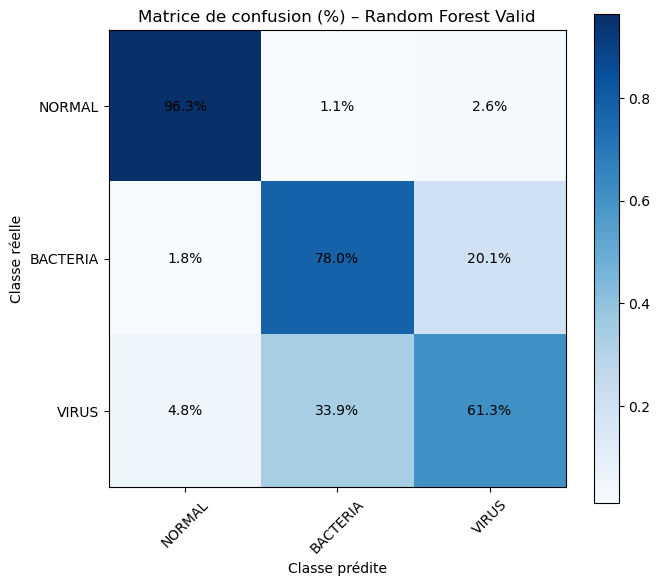

```python
# Matrice de confusion
cm_valid = confusion_matrix(y_valid, y_pred_valid)

# Normalisation par ligne (classe réelle)
cm_normalized = cm_valid.astype(float) / cm_valid.sum(axis=1, keepdims=True)

plt.figure(figsize=(7, 6))
plt.imshow(cm_normalized, cmap="Blues")
plt.colorbar()

plt.xticks(
    np.arange(len(class_names)),
    class_names,
    rotation=45
)

plt.yticks(
    np.arange(len(class_names)),
    class_names
)

# Affichage des pourcentages dans chaque case
for i in range(len(class_names)):
    for j in range(len(class_names)):
        plt.text(
            j,
            i,
            f"{cm_normalized[i, j]*100:.1f}%",
            ha="center",
            va="center",
            color="black"
        )

plt.xlabel("Classe prédite")
plt.ylabel("Classe réelle")
plt.title("Matrice de confusion (%) – Random Forest Valid")

plt.tight_layout()
plt.show()
```

```python
for i, true_class in enumerate(class_names):
    for j, pred_class in enumerate(class_names):
        print(
            f"Réel={true_class}, Prédit={pred_class} : {cm_valid[i,j]}")
```

```
Réel=NORMAL, Prédit=NORMAL : 260
Réel=NORMAL, Prédit=BACTERIA : 3
Réel=NORMAL, Prédit=VIRUS : 7
Réel=BACTERIA, Prédit=NORMAL : 8
Réel=BACTERIA, Prédit=BACTERIA : 341
Réel=BACTERIA, Prédit=VIRUS : 88
Réel=VIRUS, Prédit=NORMAL : 12
Réel=VIRUS, Prédit=BACTERIA : 84
Réel=VIRUS, Prédit=VIRUS : 152
```

```python
for classe, nom in enumerate(class_names):

    TP = cm_valid[classe, classe]

    FN = cm_valid[classe, :].sum() - TP

    FP = cm_valid[:, classe].sum() - TP

    TN = cm_valid.sum() - TP - FN - FP

    print(f"\n--- {nom} vs reste ---")
    print(f"TP : {TP}")
    print(f"FP : {FP}")
    print(f"FN : {FN}")
    print(f"TN : {TN}")
```

```
--- NORMAL vs reste ---
TP : 260
FP : 20
FN : 10
TN : 665

--- BACTERIA vs reste ---
TP : 341
FP : 87
FN : 96
TN : 431

--- VIRUS vs reste ---
TP : 152
FP : 95
FN : 96
TN : 612
```

# Essai avec un seuil de décision pour classification : sur le jeu de validation

## Seuils pour maximiser la détection des NORMAL vs PNEUMONIE, puis BACTERIA vs VIRUS

Sur le jeu de validation pour ne pas optimiser sur des données déjà "vues" par le modèle 2 scénarios : - scénario 1 : optimiser le recall pour limiter les faux négatifs - scénario 2 : optimiser l'équilibre entre faux positifs et faux négatifs

### Scénario 1 : limiter au maximum les FN pour la catégorie NORMAL

```python
proba_valid_normal = y_pred_proba_valid[:, 0] # Probabilité d'être NORMAL selon le modèle
proba_valid_bacteria = y_pred_proba_valid[:, 1] # Probabilité d'être BACTERIE selon le modèle
proba_valid_virus = y_pred_proba_valid[:, 2] # Probabilité d'être VIRUS selon le modèle

# 1. On isole la probabilité globale d'être MALADE (Bacteria ou Virus)
# C'est l'inverse de la probabilité d'être sain (Normal)
proba_valid_malade = 1 - proba_valid_normal
```

```python
thresholds = np.linspace(0.05, 0.95, 300)
rows = []
#la classe d'intérêt (1 / True / Positive) correspond aux PNEUMONIES.
# Donc tout ce qui n'est pas NORMAL (différent de 0) devient True.
y_valid_malade = (y_valid != 0)

for t in thresholds:
    y_pred = (proba_valid_malade >= t).astype(int)
    TN, FP, FN, TP = confusion_matrix(y_valid_malade, y_pred).ravel()

    rows.append({
        "threshold": t,
        "FN": FN,
        "FP": FP,
        "recall": TP / (TP + FN),
        "fpr": FP / (FP + TN) # faux positifs / total des vrais négatifs
    })

df_thresh = pd.DataFrame(rows)
```

```python
df_thresh.head()
```

|  | threshold | FN | FP | recall | fpr |
| --- | --- | --- | --- | --- | --- |
| 0 | 0.05000 | 2 | 78 | 0.99708 | 0.288889 |
| 1 | 0.05301 | 2 | 75 | 0.99708 | 0.277778 |
| 2 | 0.05602 | 2 | 72 | 0.99708 | 0.266667 |
| 3 | 0.05903 | 2 | 71 | 0.99708 | 0.262963 |
| 4 | 0.06204 | 2 | 68 | 0.99708 | 0.251852 |

```python
print(df_thresh["recall"].min())
print(df_thresh["recall"].max())
print(df_thresh["fpr"].min())
print(df_thresh["fpr"].max())
```

```
0.8948905109489051
0.997080291970803
0.011111111111111112
0.28888888888888886
```

```python
df_sc1 = df_thresh[
    (df_thresh["recall"] >= 0.98)
]
```

```python
best_row_sc1 = (
    df_sc1
    .query(f"fpr <= {df_sc1['fpr'].min()}")
    .sort_values("FN")
    .iloc[0]
)

print(best_row_sc1)
```

```
threshold     0.426254
FN           13.000000
FP           17.000000
recall        0.981022
fpr           0.062963
Name: 125, dtype: float64
```

```python
best_threshold_sc1 = best_row_sc1["threshold"]

best_threshold_sc1
```

```
np.float64(0.42625418060200665)
```

### Scénario 2 : Limiter les FN sans trop pénaliser les FP : indice de Younden

```python
#TROUVER LES MEILLEURS SEUILS POUR CHAQUE CLASSE
from sklearn.metrics import roc_curve

best_thresholds = {}

class_indices = [0, 1, 2]

# 2. Boucler sur chaque classe pour trouver son seuil optimal
for i, class_name in zip(class_indices, class_names):
    # Créer un y_valid binaire pour la classe en cours (1 si c'est la classe, 0 sinon)
    y_valid_binary = (y_valid == i).astype(int)

    # Récupérer les probabilités pour cette classe spécifique
    scores_for_class = y_pred_proba_valid[:, i]

    # Calculer la courbe ROC
    fpr, tpr, thresholds = roc_curve(y_valid_binary, scores_for_class)

    # Calculer l'indice de Youden pour chaque seuil
    youden_index = tpr - fpr

    # PIÈGE : On ignore le tout premier seuil (index 0) s'il vaut l'infini
    if thresholds[0] == np.inf or np.isinf(thresholds[0]):
        # On force l'indice de Youden du seuil infini à -1 pour l'éliminer
        youden_index[0] = -1

    # Trouver l'index du score maximum
    idx_optimal = np.argmax(youden_index)

    # Stocker le meilleur seuil
    best_thresholds[class_name] = thresholds[idx_optimal]

print("Seuils optimaux par classe :", best_thresholds)
```

```
Seuils optimaux par classe : {'NORMAL': np.float64(0.26151511196762484), 'BACTERIA': np.float64(0.3431202274566225), 'VIRUS': np.float64(0.2843101425378642)}
```

```python
best_threshold_sc2 = best_thresholds['NORMAL']

best_threshold_sc2
```

```
np.float64(0.26151511196762484)
```

## Performances jeu de test sans seuil

```python
y_pred= svc.predict(X_test_pca)
y_pred_proba_test = svc.predict_proba(X_test_pca)
```

```python
print(y_pred_proba_test)
```

[output not shown]

[output cut: 249 more lines]

[output not shown]

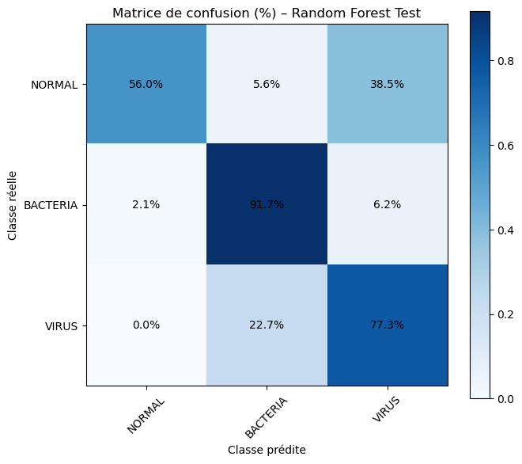

```python
# Matrice de confusion
cm_test = confusion_matrix(y_test, y_pred)

# Normalisation par ligne (classe réelle)
cm_normalized = cm_test.astype(float) / cm_test.sum(axis=1, keepdims=True)

# Noms des classes
class_names = ["NORMAL", "BACTERIA", "VIRUS"]

plt.figure(figsize=(7, 6))
plt.imshow(cm_normalized, cmap="Blues")
plt.colorbar()

plt.xticks(
    np.arange(len(class_names)),
    class_names,
    rotation=45
)

plt.yticks(
    np.arange(len(class_names)),
    class_names
)

# Affichage des pourcentages dans chaque case
for i in range(len(class_names)):
    for j in range(len(class_names)):
        plt.text(
            j,
            i,
            f"{cm_normalized[i, j]*100:.1f}%",
            ha="center",
            va="center",
            color="black"
        )

plt.xlabel("Classe prédite")
plt.ylabel("Classe réelle")
plt.title("Matrice de confusion (%) – Random Forest Test")

plt.tight_layout()
plt.show()
```

```python
roc_auc = roc_auc_score(
    y_test,
    y_pred_proba_test,
    multi_class="ovr") # capacité globale du modèle à séparer les 3 classes, indépendamment du seuil

print(f"ROC-AUC (test) : {roc_auc:.3f}")
```

```
ROC-AUC (test) : 0.917
```

```python
print(classification_report(
        y_test,
        y_pred,
        target_names=[
            "NORMAL",
            "BACTERIA",
            "VIRUS"
        ]
    ))
```

```
              precision    recall  f1-score   support

      NORMAL       0.99      0.56      0.72       234
    BACTERIA       0.71      0.92      0.80        48
       VIRUS       0.15      0.77      0.26        22

    accuracy                           0.63       304
   macro avg       0.62      0.75      0.59       304
weighted avg       0.89      0.63      0.70       304
```

```python
class_names = ["NORMAL", "BACTERIA", "VIRUS"]

for i, true_class in enumerate(class_names):
    for j, pred_class in enumerate(class_names):
        print(
            f"Réel={true_class}, Prédit={pred_class} : {cm_test[i,j]}")
```

```
Réel=NORMAL, Prédit=NORMAL : 131
Réel=NORMAL, Prédit=BACTERIA : 13
Réel=NORMAL, Prédit=VIRUS : 90
Réel=BACTERIA, Prédit=NORMAL : 1
Réel=BACTERIA, Prédit=BACTERIA : 44
Réel=BACTERIA, Prédit=VIRUS : 3
Réel=VIRUS, Prédit=NORMAL : 0
Réel=VIRUS, Prédit=BACTERIA : 5
Réel=VIRUS, Prédit=VIRUS : 17
```

## Performances jeu de test avec seuil

```python
# classement "en cascade" des prédictions en fonction des seuils des 2 scénarios
# d'abord on applique le seuil optimisé pour la distinction NORMAL/MALADE,
# puis on reclassifie BACTERIA et VIRUS avec les seuils optimaux respectifs

def predict_cascade(y_prob_matrix, thresh_malade, thresh_bacteria, thresh_virus):
    """
    y_prob_matrix : probabilités de predict_proba() [NORMAL, BACTERIA, VIRUS]
    thresh_malade : seuil de détection de la maladie (Scénario 1 ou Youden)
    thresh_bacteria : seuil Youden pour BACTERIA
    thresh_virus : seuil Youden pour VIRUS
    """
    final_predictions = []

    for probs in y_prob_matrix:
        # 1. On calcule le risque d'être malade
        prob_malade = 1 - probs[0]

        # ÉTAPE 1 : Si le risque de maladie dépasse notre seuil de sécurité
        if prob_malade >= thresh_malade:

            # ÉTAPE 2 : Le patient est malade. On utilise les seuils Youden pour Bacteria vs Virus
            score_bacteria = probs[1] / (thresh_bacteria if thresh_bacteria > 0 else 1e-6)
            score_virus = probs[2] / (thresh_virus if thresh_virus > 0 else 1e-6)

            if score_bacteria > score_virus:
                final_predictions.append(1) # Prédit BACTERIA
            else:
                final_predictions.append(2) # Prédit VIRUS
        else:
            # Le risque est trop faible, le patient est sain
            final_predictions.append(0) # Prédit NORMAL

    return np.array(final_predictions)
```

### Scénario 1

```python
y_pred_sc1 = predict_cascade(
    y_pred_proba_test,
    thresh_malade=best_threshold_sc1,
    thresh_bacteria=1,                 # On met 1 pour ne pas modifier le score brut
    thresh_virus=1)
```

```python
cm_sc1 = confusion_matrix(y_test, y_pred_sc1)

print(f"Seuil utilisé : {best_threshold_sc1}")

print(classification_report(
        y_test,
        y_pred_sc1,
        target_names=[
            "NORMAL",
            "BACTERIA",
            "VIRUS"
        ]
    ))
```

```
Seuil utilisé : 0.42625418060200665
              precision    recall  f1-score   support

      NORMAL       1.00      0.42      0.59       234
    BACTERIA       0.52      0.96      0.67        48
       VIRUS       0.15      0.77      0.25        22

    accuracy                           0.53       304
   macro avg       0.55      0.72      0.50       304
weighted avg       0.86      0.53      0.58       304
```

```python
class_names = ["NORMAL", "BACTERIA", "VIRUS"]

for i, true_class in enumerate(class_names):
    for j, pred_class in enumerate(class_names):
        print(
            f"Réel={true_class}, Prédit={pred_class} : {cm_sc1[i,j]}")
```

```
Réel=NORMAL, Prédit=NORMAL : 99
Réel=NORMAL, Prédit=BACTERIA : 38
Réel=NORMAL, Prédit=VIRUS : 97
Réel=BACTERIA, Prédit=NORMAL : 0
Réel=BACTERIA, Prédit=BACTERIA : 46
Réel=BACTERIA, Prédit=VIRUS : 2
Réel=VIRUS, Prédit=NORMAL : 0
Réel=VIRUS, Prédit=BACTERIA : 5
Réel=VIRUS, Prédit=VIRUS : 17
```

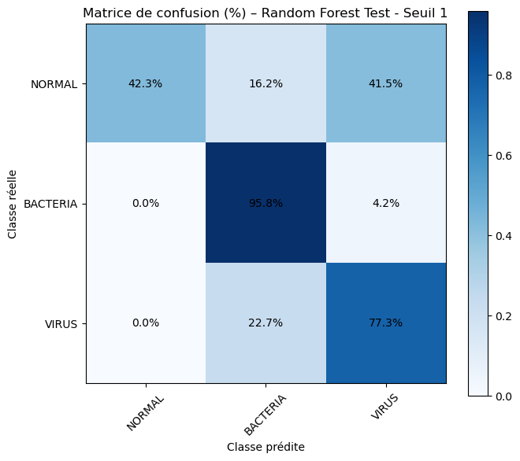

```python
# Normalisation par ligne (classe réelle)
cm_normalized = cm_sc1.astype(float) / cm_sc1.sum(axis=1, keepdims=True)

# Noms des classes
class_names = ["NORMAL", "BACTERIA", "VIRUS"]

plt.figure(figsize=(7, 6))
plt.imshow(cm_normalized, cmap="Blues")
plt.colorbar()

plt.xticks(
    np.arange(len(class_names)),
    class_names,
    rotation=45
)

plt.yticks(
    np.arange(len(class_names)),
    class_names
)

# Affichage des pourcentages dans chaque case
for i in range(len(class_names)):
    for j in range(len(class_names)):
        plt.text(
            j,
            i,
            f"{cm_normalized[i, j]*100:.1f}%",
            ha="center",
            va="center",
            color="black"
        )

plt.xlabel("Classe prédite")
plt.ylabel("Classe réelle")
plt.title("Matrice de confusion (%) – Random Forest Test - Seuil 1")

plt.tight_layout()
plt.show()
```

### Scénario 2

```python
seuil_maladie_youden = 1 - best_thresholds['NORMAL']

y_pred_sc2 = predict_cascade(
    y_pred_proba_test,
    thresh_malade=seuil_maladie_youden,       # Seuil Youden converti en risque maladie
    thresh_bacteria=best_thresholds['BACTERIA'], # Seuil Youden Bacteria
    thresh_virus=best_thresholds['VIRUS']        # Seuil Youden Virus
)
```

```python
cm_sc2 = confusion_matrix(y_test, y_pred_sc2)

print(f"Seuil utilisé : {best_threshold_sc2}")

print(classification_report(
        y_test,
        y_pred_sc2,
        target_names=[
            "NORMAL",
            "BACTERIA",
            "VIRUS"
        ]
    ))
```

```
Seuil utilisé : 0.26151511196762484
              precision    recall  f1-score   support

      NORMAL       0.99      0.59      0.74       234
    BACTERIA       0.63      0.94      0.76        48
       VIRUS       0.18      0.77      0.29        22

    accuracy                           0.65       304
   macro avg       0.60      0.77      0.59       304
weighted avg       0.88      0.65      0.71       304
```

```python
class_names = ["NORMAL", "BACTERIA", "VIRUS"]

for i, true_class in enumerate(class_names):
    for j, pred_class in enumerate(class_names):
        print(
            f"Réel={true_class}, Prédit={pred_class} : {cm_sc2[i,j]}")
```

```
Réel=NORMAL, Prédit=NORMAL : 137
Réel=NORMAL, Prédit=BACTERIA : 21
Réel=NORMAL, Prédit=VIRUS : 76
Réel=BACTERIA, Prédit=NORMAL : 1
Réel=BACTERIA, Prédit=BACTERIA : 45
Réel=BACTERIA, Prédit=VIRUS : 2
Réel=VIRUS, Prédit=NORMAL : 0
Réel=VIRUS, Prédit=BACTERIA : 5
Réel=VIRUS, Prédit=VIRUS : 17
```

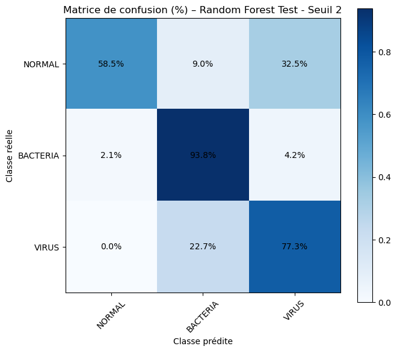

```python
# Normalisation par ligne (classe réelle)
cm_normalized = cm_sc2.astype(float) / cm_sc2.sum(axis=1, keepdims=True)

# Noms des classes
class_names = ["NORMAL", "BACTERIA", "VIRUS"]

plt.figure(figsize=(7, 6))
plt.imshow(cm_normalized, cmap="Blues")
plt.colorbar()

plt.xticks(
    np.arange(len(class_names)),
    class_names,
    rotation=45
)

plt.yticks(
    np.arange(len(class_names)),
    class_names
)

# Affichage des pourcentages dans chaque case
for i in range(len(class_names)):
    for j in range(len(class_names)):
        plt.text(
            j,
            i,
            f"{cm_normalized[i, j]*100:.1f}%",
            ha="center",
            va="center",
            color="black"
        )

plt.xlabel("Classe prédite")
plt.ylabel("Classe réelle")
plt.title("Matrice de confusion (%) – Random Forest Test - Seuil 2")

plt.tight_layout()
plt.show()
```

# Quelles images sont encore des FN ?

```python
df_test = df[df["split"] == "test"].reset_index(drop=True)

fn_idx = np.where((y_test != 0) & (y_pred_sc2 == 0))[0]
```

```python
def show_errors(df_test, fn_indices, max_images=10):
    n = min(len(fn_indices), max_images)

    plt.figure(figsize=(15, 4 * ((n + 3) // 4)))

    for i, idx in enumerate(fn_indices[:n]):
        img_path = df_test.loc[idx, "path"]
        label = df_test.loc[idx, "label"]
        patient_id = df_test.loc[idx, "patient_id"]

        img = Image.open(img_path).convert("L")

        plt.subplot((n + 3) // 4, 4, i + 1)
        plt.imshow(img, cmap="gray")
        plt.axis("off")
        plt.title(f"FN – {label}\nPatient ID: {patient_id}")

    plt.suptitle("Faux négatifs (cas de PNEUMONIA prédit NORMAL)", fontsize=16)
    plt.tight_layout()
    plt.show()
```

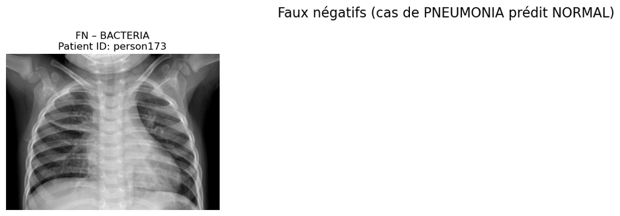

```python
show_errors(df_test, fn_idx, max_images=10)
```